# Clustering Project (Creating Customer Segments)

## Getting Started

In this project, we will analyze a dataset containing data on various customers' annual spending amounts (reported in *monetary units*) of diverse product categories for internal structure. One goal of this project is to best describe the variation in the different types of customers that a wholesale distributor interacts with. Doing so would equip the distributor with insight into how to best structure their delivery service to meet the needs of each customer.

```python
import numpy as np
import pandas as pd
import warnings
warnings.filterwarnings("ignore")
import matplotlib.cm as cm
import matplotlib.pyplot as plt
import seaborn as sns

# Pretty display for notebooks
%matplotlib inline
```

```python
# Load the wholesale customers dataset
try:
    data = pd.read_csv("customers.csv")
    #
    print("Wholesale customers dataset has {} samples with {} features each.".format(*data.shape))
except:
    print("Dataset could not be loaded. Is the dataset missing?")
```

```
Wholesale customers dataset has 440 samples with 8 features each.
```

```python
data.head()
```

|  | Channel | Region | Fresh | Milk | Grocery | Frozen | Detergents_Paper | Delicatessen |
| --- | --- | --- | --- | --- | --- | --- | --- | --- |
| 0 | 2 | 3 | 12669 | 9656 | 7561 | 214 | 2674 | 1338 |
| 1 | 2 | 3 | 7057 | 9810 | 9568 | 1762 | 3293 | 1776 |
| 2 | 2 | 3 | 6353 | 8808 | 7684 | 2405 | 3516 | 7844 |
| 3 | 1 | 3 | 13265 | 1196 | 4221 | 6404 | 507 | 1788 |
| 4 | 2 | 3 | 22615 | 5410 | 7198 | 3915 | 1777 | 5185 |

> For the purposes of this project, the features `'Channel'` and `'Region'` will be excluded in the analysis — with focus instead on the six product categories recorded for customers.

```python
# axis = 1 will drop by column wise
data.drop(['Region', 'Channel'], axis = 1, inplace = True)
data.head()
```

|  | Fresh | Milk | Grocery | Frozen | Detergents_Paper | Delicatessen |
| --- | --- | --- | --- | --- | --- | --- |
| 0 | 12669 | 9656 | 7561 | 214 | 2674 | 1338 |
| 1 | 7057 | 9810 | 9568 | 1762 | 3293 | 1776 |
| 2 | 6353 | 8808 | 7684 | 2405 | 3516 | 7844 |
| 3 | 13265 | 1196 | 4221 | 6404 | 507 | 1788 |
| 4 | 22615 | 5410 | 7198 | 3915 | 1777 | 5185 |

> Note that the dataset is composed of six important product categories: **'Fresh'**, **'Milk'**, **'Grocery'**, **'Frozen'**, **'Detergents_Paper'**, and **'Delicatessen'** which customer is intended to buy in certain quantity. Consider what each category represents in terms of products you could purchase.We will cluster or group customer based on their buying quantity of different Product and will give them category.

```python
data.describe()
```

|  | Fresh | Milk | Grocery | Frozen | Detergents_Paper | Delicatessen |
| --- | --- | --- | --- | --- | --- | --- |
| count | 440.000000 | 440.000000 | 440.000000 | 440.000000 | 440.000000 | 440.000000 |
| mean | 12000.297727 | 5796.265909 | 7951.277273 | 3071.931818 | 2881.493182 | 1524.870455 |
| std | 12647.328865 | 7380.377175 | 9503.162829 | 4854.673333 | 4767.854448 | 2820.105937 |
| min | 3.000000 | 55.000000 | 3.000000 | 25.000000 | 3.000000 | 3.000000 |
| 25% | 3127.750000 | 1533.000000 | 2153.000000 | 742.250000 | 256.750000 | 408.250000 |
| 50% | 8504.000000 | 3627.000000 | 4755.500000 | 1526.000000 | 816.500000 | 965.500000 |
| 75% | 16933.750000 | 7190.250000 | 10655.750000 | 3554.250000 | 3922.000000 | 1820.250000 |
| max | 112151.000000 | 73498.000000 | 92780.000000 | 60869.000000 | 40827.000000 | 47943.000000 |

### Implementation: Selecting Samples

> To get a better understanding of the customers and how their data will transform through the analysis, it would be best to select a few sample data points and explore them in more detail. In the code block below, add **three** indices of your choice to the `indices` list which will represent the customers to track. It is suggested to try different sets of samples until you obtain customers that are different from one another.

```python
# I am selecting three indices of my choice  to take sample from the dataset Row 25,50 and 75
indices = [25,50,75]
samples = pd.DataFrame(data.loc[indices], columns = data.columns)
print("Chosen samples of wholesale customers dataset:")
samples
```

```
Chosen samples of wholesale customers dataset:
```

|  | Fresh | Milk | Grocery | Frozen | Detergents_Paper | Delicatessen |
| --- | --- | --- | --- | --- | --- | --- |
| 25 | 16165 | 4230 | 7595 | 201 | 4003 | 57 |
| 50 | 6269 | 1095 | 1980 | 3860 | 609 | 2162 |
| 75 | 20398 | 1137 | 3 | 4407 | 3 | 975 |

> Resetting Index will give you Row no from 0,1,2 otherwise it will get Index No of Row from Original Dataset

```python
samples.reset_index(drop = True)
```

|  | Fresh | Milk | Grocery | Frozen | Detergents_Paper | Delicatessen |
| --- | --- | --- | --- | --- | --- | --- |
| 0 | 16165 | 4230 | 7595 | 201 | 4003 | 57 |
| 1 | 6269 | 1095 | 1980 | 3860 | 609 | 2162 |
| 2 | 20398 | 1137 | 3 | 4407 | 3 | 975 |

- What kind of customer could each of the three samples we 've chosen represent?

**Mean values in data.describe() as describe above:**

- Fresh: 12000.2977
- Milk: 5796.2
- Grocery: 7951.3
- Detergents_paper: 2881.4
- Delicatessen: 1524.8

> Now we will compare these 3 Sample values from their Mean Values of Six Categories.We will See at which Percentile each value of 6 Categories belong to 3 Sample so that we can classify each Sample belongs to specific Customer

```python
#This will give Percentile of each Item from their mean.at which percentile each value lie in the Distribution
pct = (data.rank(pct=True).loc[indices]*100).astype(int)
pct
```

|  | Fresh | Milk | Grocery | Frozen | Detergents_Paper | Delicatessen |
| --- | --- | --- | --- | --- | --- | --- |
| 25 | 73 | 56 | 65 | 7 | 75 | 4 |
| 50 | 40 | 15 | 20 | 76 | 44 | 81 |
| 75 | 82 | 17 | 0 | 79 | 0 | 50 |

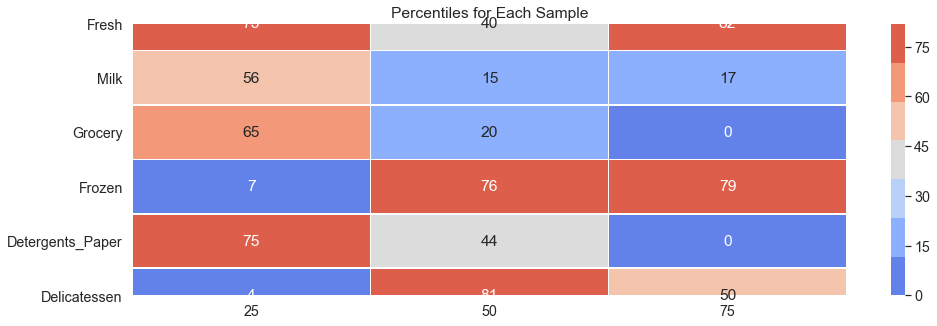

```python
plt.figure(figsize = (16,5))
sns.set(font_scale=1.3)
plt.title('Percentiles for Each Sample')
sns.heatmap(pct.transpose(), linewidths=0.5, cmap=sns.color_palette("coolwarm", 7), annot=True)
plt.show()
```

**Answer:**

### Customer Index : 25 (Index 0)

- Major Spending: Fresh, DetergentS_Paper (Based on "HeatMap" & "> mean_value")
- Medium Spending: Milk, Grocery (Based on "HeatMap" & "Around mean_value")
- Minor Spending: Frozen, Delicatessen (Based on "HeatMap" & "< mean_value")
  - **Conclusion:** `*Small Retail Store.*`

### Customer Index : 50 (Index 1)

- Major Spending: Frozen, Delicatessen (Based on "HeatMap" & "> mean_value")
- Medium Spending: Fresh, Detergents_Paper (Based on "HeatMap" & "Around mean_value")
- Minor Spending: Milk, Grocery (Based on "HeatMap" & "< mean_value")
  - **Conclusion:** `*Resturent*`

### Customer Index : 75 (Index 2)

- Major Spending: Frozen, Fresh (Based on "HeatMap" & "> mean_value")
- Medium Spending: Delicatessen (Based on "HeatMap" & "Around mean_value")
- Minor Spending: Milk, Grocery, Detergents_Paper (Based on "HeatMap" & "< mean_value")
  - **Conclusion:** `*Supplier (with Small Resturent Business) / Supermarket (with attached Small Resturent)*`

### Implementation: Feature Relevance

> We will take R-Squared of Every feature column which could be predicted by othere columns in the DataSet as We get Rsquared in R to get How much variability is defined by other columns.If Rsquared is higher that mean other feature is predicting target column pretty well If Rsquared is low that mean other column is not able to predict the targeted column.

```python
from sklearn.model_selection import train_test_split
from sklearn.tree import DecisionTreeRegressor

features = list(data.columns)
for feature in features:

    # TODO: Make a copy of the DataFrame, using the 'drop' function to drop the given feature
    new_data = data.drop([feature], axis=1)

    # TODO: Split the data into training and testing sets(0.25) using the given feature as the target
    # Set a random state.
    X_train, X_test, y_train, y_test = train_test_split(new_data, data[feature], test_size=0.25, random_state=42)

    # TODO: Create a decision tree regressor and fit it to the training set
    regressor = DecisionTreeRegressor(random_state=42).fit(X_train, y_train)

    # TODO: Report the score of the prediction using the testing set
    score = regressor.score(X_test, y_test)
    print('R2 score for {} as dependent variable: {}'.format(feature, score))
```

```
R2 score for Fresh as dependent variable: -0.38574971020407384
R2 score for Milk as dependent variable: 0.15627539501732116
R2 score for Grocery as dependent variable: 0.6818840085440834
R2 score for Frozen as dependent variable: -0.21013589012491396
R2 score for Detergents_Paper as dependent variable: 0.27166698062685013
R2 score for Delicatessen as dependent variable: -2.254711537203931
```

### Question 2

- Which feature did you attempt to predict?
- What was the reported prediction score?
- Is this feature necessary for identifying customers' spending habits?

**Hint:** The coefficient of determination, Rsquared, is scored between 0 and 1, with 1 being a perfect fit. A negative Rsquared implies the model fails to fit the data. If you get a low score for a particular feature, that give us to beleive that that feature point is hard to predict using the other features, thereby making it an important feature to consider when considering relevance.

**Answer:**

- I have looped and predicted every single feature as a dependent variable with the results shown above.
- *"Delicatessen"* as a dependent variable has **Most Negative Rsquared score (Relative to others)**.
  - Meaning, the values of the delicatessen category (feature) contain very little information about the target variable or cannot be predicted by the other features in the dataset. Therefore, the feature is NOT necessarily redundant but may contain useful information not contained in the other features.
- *"Fresh", "Frozen"* as dependent variables have **Negative Rsquared scores**.
  - This imply that they are necessary for identifying customers' spending habits because the remaining features cannot explain the variation in them.
- *"Detergents_Paper", "Milk"* as dependent variables have **Very Low Positve Rsquared scores**.
  - These low scores imply that these are necessary for identifying customers' spending habits.
- *"Grocery"* as dependent variable has **Most Positve Rsquared scores (Relative to others)**.
  - This score is a bit far from 1 but relative to the others this appears much higher.
  - Basically the Model was able to predict this feature "Grocery" easily with the help of other features. Hence, this may be NOT as necessary when compared to the other features for identifying customers' spending habits.

### Visualize Feature Distributions

To get a better understanding of the dataset, we can construct a scatter matrix of each of the six product features present in the data. If you found that the feature you attempted to predict above is relevant for identifying a specific customer, then the scatter matrix below may not show any correlation between that feature and the others. Conversely, if you believe that feature is not relevant for identifying a specific customer, the scatter matrix might show a correlation between that feature and another feature in the data. Run the code block below to produce a scatter matrix.

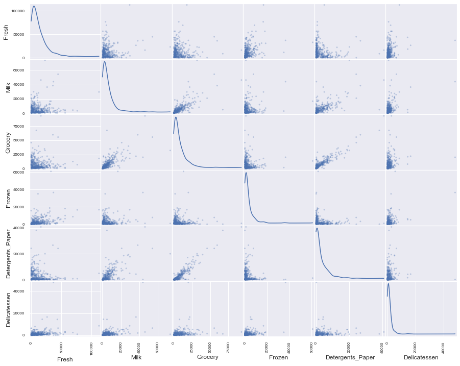

```python
# Produce a scatter matrix for each pair of features in the data
pd.plotting.scatter_matrix(data, alpha = 0.3, figsize = (15,12), diagonal = 'kde');
```

## Data Preprocessing

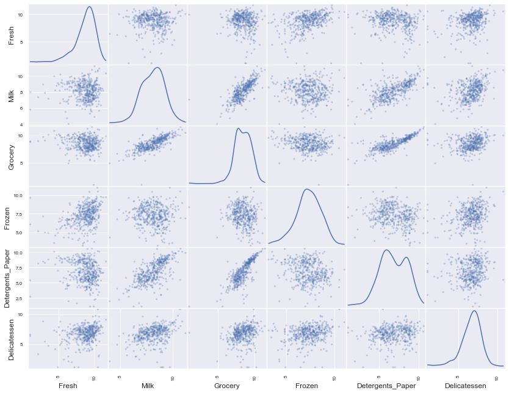

```python
# TODO: Scale the data using the natural logarithm
log_data = np.log(data)

# TODO: Scale the sample data using the natural logarithm
log_samples = np.log(samples)

# Produce a scatter matrix for each pair of newly-transformed features
pd.plotting.scatter_matrix(log_data, alpha = 0.3, figsize = (14,11), diagonal = 'kde');
```

> **Hint:** We can also use corr() to get the feature correlations and then visualize them using a heatmap .The data that would be fed into the heatmap would be the correlation values, for eg: `data.corr()`) to gain further insight.Heatmap is used to know Correlation among other columns/features

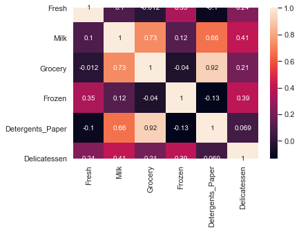

```python
sns.heatmap(data.corr(), annot=True)
```

1. *The following pairs of features seem to indicate some correlation:*
   - **Detergents_Paper and Grocery:** We can see a linear correlation here that's apparently strongly correlated with a coefficient of 0.92.
   - **Grocery and Milk:** Another linear correlation with almost similar strength to (Detergents_Paper~Milk) of 0.73.
   - **Detergents_Paper and Milk:** Another linear correlation, but less clear than (Milk~Grocery) - with a correlation coefficient of 0.66.
2. These features that are strongly correlated does lend credence to our initial claim that Grocery may not be necessary for identifying customers' spending habits. Grocery has a high correlation with Detergents_Paper and Milk that corresponds to a relatively high R2 score when we regress Grocery on all other features.

### Observation

After applying a natural logarithm scaling to the data, the distribution of each feature should appear much more normal

```python
log_samples
```

|  | Fresh | Milk | Grocery | Frozen | Detergents_Paper | Delicatessen |
| --- | --- | --- | --- | --- | --- | --- |
| 25 | 9.690604 | 8.349957 | 8.935245 | 5.303305 | 8.294799 | 4.043051 |
| 50 | 8.743372 | 6.998510 | 7.590852 | 8.258422 | 6.411818 | 7.678789 |
| 75 | 9.923192 | 7.036148 | 1.098612 | 8.390949 | 1.098612 | 6.882437 |

### Distribution of Data before Normalizing the data: (data)

```
Distribution before Normalizing the data
```

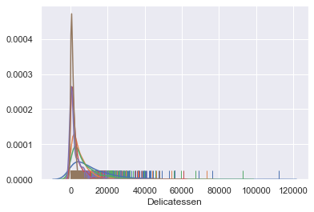

```python
print ("Distribution before Normalizing the data")
sns.set(color_codes=True)
plt.show()
sns.distplot(data['Fresh'],rug=True, hist=False)
sns.distplot(data['Milk'], rug=True, hist=False)
sns.distplot(data['Grocery'], rug=True, hist=False)
sns.distplot(data['Frozen'], rug=True, hist=False)
sns.distplot(data['Detergents_Paper'], rug=True, hist=False)
sns.distplot(data['Delicatessen'], rug=True, hist=False)
plt.show()
```

### Distribution of Data after Normalizing the data by log Transformation: (log_data)

```
Distribution after Normalizing the data
```

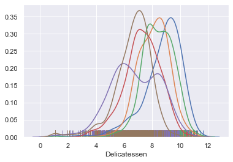

```python
print ("Distribution after Normalizing the data")
sns.set(color_codes=True)
plt.show()
sns.distplot(log_data['Fresh'],rug=True, hist=False)
sns.distplot(log_data['Milk'], rug=True, hist=False)
sns.distplot(log_data['Grocery'], rug=True, hist=False)
sns.distplot(log_data['Frozen'], rug=True, hist=False)
sns.distplot(log_data['Detergents_Paper'], rug=True, hist=False)
sns.distplot(log_data['Delicatessen'], rug=True, hist=False)
plt.show()
```

### Implementation: Outlier Detection

Detecting outliers in the data is extremely important in the data preprocessing step of any analysis. The presence of outliers can often skew results which take into consideration these data points. There are many "rules of thumb" for what constitutes an outlier in a dataset. Here, we will use Tukey's Method for identfying outliers: An *outlier step* is calculated as 1.5 times the interquartile range (IQR). A data point with a feature that is beyond an outlier step outside of the IQR for that feature is considered abnormal.

In the code block below, you will need to implement the following:

- Assign the value of the 25th percentile for the given feature to `Q1`. Use `np.percentile` for this.
- Assign the value of the 75th percentile for the given feature to `Q3`. Again, use `np.percentile`.
- Assign the calculation of an outlier step for the given feature to `step`.
- Optionally remove data points from the dataset by adding indices to the `outliers` list.

```python
# For each feature find the data points with extreme high or low values
outliers = list()
for feature in log_data.keys():

    # TODO: Calculate Q1 (25th percentile of the data) for the given feature
    Q1 = np.percentile(log_data[feature],25)

    # TODO: Calculate Q3 (75th percentile of the data) for the given feature
    Q3 = np.percentile(log_data[feature],75)

    # TODO: Use the interquartile range to calculate an outlier step (1.5 times the interquartile range)
    step = 1.5 * (Q3 - Q1)

    # Display the outliers
    print("Data points considered outliers for the feature '{}':".format(feature))
    out = log_data[~((log_data[feature] >= Q1 - step) & (log_data[feature] <= Q3 + step))]
    display(out)
    outliers = outliers + list(out.index.values)
```

```
Data points considered outliers for the feature 'Fresh':
```

|  | Fresh | Milk | Grocery | Frozen | Detergents_Paper | Delicatessen |
| --- | --- | --- | --- | --- | --- | --- |
| 65 | 4.442651 | 9.950323 | 10.732651 | 3.583519 | 10.095388 | 7.260523 |
| 66 | 2.197225 | 7.335634 | 8.911530 | 5.164786 | 8.151333 | 3.295837 |
| 81 | 5.389072 | 9.163249 | 9.575192 | 5.645447 | 8.964184 | 5.049856 |
| 95 | 1.098612 | 7.979339 | 8.740657 | 6.086775 | 5.407172 | 6.563856 |
| 96 | 3.135494 | 7.869402 | 9.001839 | 4.976734 | 8.262043 | 5.379897 |
| 128 | 4.941642 | 9.087834 | 8.248791 | 4.955827 | 6.967909 | 1.098612 |
| 171 | 5.298317 | 10.160530 | 9.894245 | 6.478510 | 9.079434 | 8.740337 |
| 193 | 5.192957 | 8.156223 | 9.917982 | 6.865891 | 8.633731 | 6.501290 |
| 218 | 2.890372 | 8.923191 | 9.629380 | 7.158514 | 8.475746 | 8.759669 |
| 304 | 5.081404 | 8.917311 | 10.117510 | 6.424869 | 9.374413 | 7.787382 |
| 305 | 5.493061 | 9.468001 | 9.088399 | 6.683361 | 8.271037 | 5.351858 |
| 338 | 1.098612 | 5.808142 | 8.856661 | 9.655090 | 2.708050 | 6.309918 |
| 353 | 4.762174 | 8.742574 | 9.961898 | 5.429346 | 9.069007 | 7.013016 |
| 355 | 5.247024 | 6.588926 | 7.606885 | 5.501258 | 5.214936 | 4.844187 |
| 357 | 3.610918 | 7.150701 | 10.011086 | 4.919981 | 8.816853 | 4.700480 |
| 412 | 4.574711 | 8.190077 | 9.425452 | 4.584967 | 7.996317 | 4.127134 |

```
Data points considered outliers for the feature 'Milk':
```

|  | Fresh | Milk | Grocery | Frozen | Detergents_Paper | Delicatessen |
| --- | --- | --- | --- | --- | --- | --- |
| 86 | 10.039983 | 11.205013 | 10.377047 | 6.894670 | 9.906981 | 6.805723 |
| 98 | 6.220590 | 4.718499 | 6.656727 | 6.796824 | 4.025352 | 4.882802 |
| 154 | 6.432940 | 4.007333 | 4.919981 | 4.317488 | 1.945910 | 2.079442 |
| 356 | 10.029503 | 4.897840 | 5.384495 | 8.057377 | 2.197225 | 6.306275 |

```
Data points considered outliers for the feature 'Grocery':
```

|  | Fresh | Milk | Grocery | Frozen | Detergents_Paper | Delicatessen |
| --- | --- | --- | --- | --- | --- | --- |
| 75 | 9.923192 | 7.036148 | 1.098612 | 8.390949 | 1.098612 | 6.882437 |
| 154 | 6.432940 | 4.007333 | 4.919981 | 4.317488 | 1.945910 | 2.079442 |

```
Data points considered outliers for the feature 'Frozen':
```

|  | Fresh | Milk | Grocery | Frozen | Detergents_Paper | Delicatessen |
| --- | --- | --- | --- | --- | --- | --- |
| 38 | 8.431853 | 9.663261 | 9.723703 | 3.496508 | 8.847360 | 6.070738 |
| 57 | 8.597297 | 9.203618 | 9.257892 | 3.637586 | 8.932213 | 7.156177 |
| 65 | 4.442651 | 9.950323 | 10.732651 | 3.583519 | 10.095388 | 7.260523 |
| 145 | 10.000569 | 9.034080 | 10.457143 | 3.737670 | 9.440738 | 8.396155 |
| 175 | 7.759187 | 8.967632 | 9.382106 | 3.951244 | 8.341887 | 7.436617 |
| 264 | 6.978214 | 9.177714 | 9.645041 | 4.110874 | 8.696176 | 7.142827 |
| 325 | 10.395650 | 9.728181 | 9.519735 | 11.016479 | 7.148346 | 8.632128 |
| 420 | 8.402007 | 8.569026 | 9.490015 | 3.218876 | 8.827321 | 7.239215 |
| 429 | 9.060331 | 7.467371 | 8.183118 | 3.850148 | 4.430817 | 7.824446 |
| 439 | 7.932721 | 7.437206 | 7.828038 | 4.174387 | 6.167516 | 3.951244 |

```
Data points considered outliers for the feature 'Detergents_Paper':
```

|  | Fresh | Milk | Grocery | Frozen | Detergents_Paper | Delicatessen |
| --- | --- | --- | --- | --- | --- | --- |
| 75 | 9.923192 | 7.036148 | 1.098612 | 8.390949 | 1.098612 | 6.882437 |
| 161 | 9.428190 | 6.291569 | 5.645447 | 6.995766 | 1.098612 | 7.711101 |

```
Data points considered outliers for the feature 'Delicatessen':
```

|  | Fresh | Milk | Grocery | Frozen | Detergents_Paper | Delicatessen |
| --- | --- | --- | --- | --- | --- | --- |
| 66 | 2.197225 | 7.335634 | 8.911530 | 5.164786 | 8.151333 | 3.295837 |
| 109 | 7.248504 | 9.724899 | 10.274568 | 6.511745 | 6.728629 | 1.098612 |
| 128 | 4.941642 | 9.087834 | 8.248791 | 4.955827 | 6.967909 | 1.098612 |
| 137 | 8.034955 | 8.997147 | 9.021840 | 6.493754 | 6.580639 | 3.583519 |
| 142 | 10.519646 | 8.875147 | 9.018332 | 8.004700 | 2.995732 | 1.098612 |
| 154 | 6.432940 | 4.007333 | 4.919981 | 4.317488 | 1.945910 | 2.079442 |
| 183 | 10.514529 | 10.690808 | 9.911952 | 10.505999 | 5.476464 | 10.777768 |
| 184 | 5.789960 | 6.822197 | 8.457443 | 4.304065 | 5.811141 | 2.397895 |
| 187 | 7.798933 | 8.987447 | 9.192075 | 8.743372 | 8.148735 | 1.098612 |
| 203 | 6.368187 | 6.529419 | 7.703459 | 6.150603 | 6.860664 | 2.890372 |
| 233 | 6.871091 | 8.513988 | 8.106515 | 6.842683 | 6.013715 | 1.945910 |
| 285 | 10.602965 | 6.461468 | 8.188689 | 6.948897 | 6.077642 | 2.890372 |
| 289 | 10.663966 | 5.655992 | 6.154858 | 7.235619 | 3.465736 | 3.091042 |
| 343 | 7.431892 | 8.848509 | 10.177932 | 7.283448 | 9.646593 | 3.610918 |

There were 5 data points that were considered outliers for more than one feature based on our definition above. So, instead of removing all outliers (which would result in us losing a lot of information), only outliers that occur for more than one feature are removed.

```python
# Select the indices for data points outlier which exists in more than one column
outliers = list(set([x for x in outliers if outliers.count(x) > 1]))
print ("Outliers exists in more than one Columns: {}".format(outliers))
```

```
Outliers exists in more than one Columns: [128, 65, 66, 75, 154]
```

```python
# Remove the outliers, if any were specified
good_data = log_data.drop(log_data.index[outliers]).reset_index(drop = True)
print("good data Rows are",len(good_data))
```

```
good data Rows are 435
```

> **Hint:** If you have datapoints that are outliers in multiple categories think about why that may be and if they warrant removal. Also note how k-means is affected by outliers and whether or not this plays a factor in your analysis of whether or not to remove them.

### Implementation: PCA

Now that the data has been scaled to a more normal distribution and has had any necessary outliers removed, we can now apply PCA to the good_data to discover which dimensions about the data best maximize the variance of features involved

```python
def pca_results(good_data, pca):
	'''
	Create a DataFrame of the PCA results
	Includes dimension feature weights and explained variance
	Visualizes the PCA results
	'''

	# Dimension indexing
	dimensions = dimensions = ['Dimension {}'.format(i) for i in range(1,len(pca.components_)+1)]

	# PCA components
	components = pd.DataFrame(np.round(pca.components_, 4), columns = list(good_data.keys()))
	components.index = dimensions

	# PCA explained variance
	ratios = pca.explained_variance_ratio_.reshape(len(pca.components_), 1)
	variance_ratios = pd.DataFrame(np.round(ratios, 4), columns = ['Explained Variance'])
	variance_ratios.index = dimensions

	# Create a bar plot visualization
	fig, ax = plt.subplots(figsize = (14,8))

	# Plot the feature weights as a function of the components
	components.plot(ax = ax, kind = 'bar');
	ax.set_ylabel("Feature Weights")
	ax.set_xticklabels(dimensions, rotation=0)


	# Display the explained variance ratios
	for i, ev in enumerate(pca.explained_variance_ratio_):
		ax.text(i-0.40, ax.get_ylim()[1] + 0.05, "Explained Variance\n          %.4f"%(ev))

	# Return a concatenated DataFrame
	return pd.concat([variance_ratios, components], axis = 1)
```

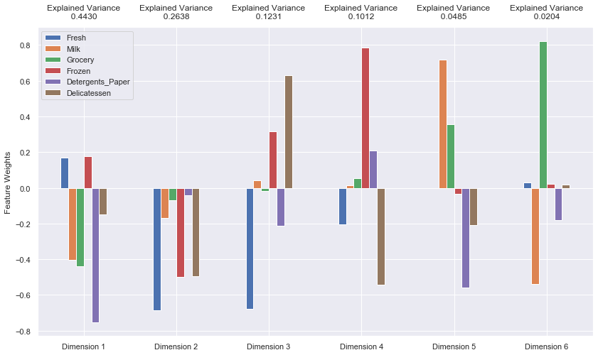

```python
from sklearn.decomposition import PCA
# TODO: Apply PCA by fitting the good data with the same number of dimensions as features
pca = PCA(n_components=6).fit(good_data)

# TODO: Transform log_samples using the PCA fit above
pca_samples = pca.transform(log_samples)

# Generate PCA results plot
pca_results = pca_results(good_data, pca)
```

```python
pca_results
```

|  | Explained Variance | Fresh | Milk | Grocery | Frozen | Detergents_Paper | Delicatessen |
| --- | --- | --- | --- | --- | --- | --- | --- |
| Dimension 1 | 0.4430 | 0.1675 | -0.4014 | -0.4381 | 0.1782 | -0.7514 | -0.1499 |
| Dimension 2 | 0.2638 | -0.6859 | -0.1672 | -0.0707 | -0.5005 | -0.0424 | -0.4941 |
| Dimension 3 | 0.1231 | -0.6774 | 0.0402 | -0.0195 | 0.3150 | -0.2117 | 0.6286 |
| Dimension 4 | 0.1012 | -0.2043 | 0.0128 | 0.0557 | 0.7854 | 0.2096 | -0.5423 |
| Dimension 5 | 0.0485 | -0.0026 | 0.7192 | 0.3554 | -0.0331 | -0.5582 | -0.2092 |
| Dimension 6 | 0.0204 | 0.0292 | -0.5402 | 0.8205 | 0.0205 | -0.1824 | 0.0197 |

```python
print(pca_results['Explained Variance'].cumsum())
```

```
Dimension 1    0.4430
Dimension 2    0.7068
Dimension 3    0.8299
Dimension 4    0.9311
Dimension 5    0.9796
Dimension 6    1.0000
Name: Explained Variance, dtype: float64
```

### Observation

Run the code below to see how the log-transformed sample data has changed after having a PCA transformation applied to it in six dimensions. Observe the numerical value for the first four dimensions of the sample points. Consider if this is consistent with your initial interpretation of the sample points.

```python
# Display sample log-data after having a PCA transformation applied
pd.DataFrame(np.round(pca_samples, 4), columns = pca_results.index.values)
```

|  | Dimension 1 | Dimension 2 | Dimension 3 | Dimension 4 | Dimension 5 | Dimension 6 |
| --- | --- | --- | --- | --- | --- | --- |
| 0 | -1.2292 | 1.5540 | -3.2462 | 0.0043 | 0.1124 | -0.0697 |
| 1 | 1.1404 | -0.6710 | 0.9823 | 0.0603 | -1.1423 | 0.0055 |
| 2 | 8.3026 | -0.4747 | 0.9774 | -1.1195 | -0.2977 | -4.3514 |

### Implementation: Dimensionality Reduction

When using principal component analysis, one of the main goals is to reduce the dimensionality of the data — in effect, reducing the complexity of the problem. Dimensionality reduction comes at a cost: Fewer dimensions used implies less of the total variance in the data is being explained. Because of this, the cumulative explained variance ratio is extremely important for knowing how many dimensions are necessary for the problem. Additionally, if a signifiant amount of variance is explained by only two or three dimensions, the reduced data can be visualized afterwards.

In the code block below, you will need to implement the following:

Assign the results of fitting PCA in two dimensions with good_data to pca. Apply a PCA transformation of good_data using pca.transform, and assign the results to reduced_data. Apply a PCA transformation of log_samples using pca.transform, and assign the results to pca_samples.

```python
# TODO: Apply PCA by fitting the good data with only two dimensions
pca = PCA(n_components=2).fit(good_data)

# TODO: Transform the good data using the PCA fit above
reduced_data = pca.transform(good_data)

# TODO: Transform log_samples using the PCA fit above
pca_samples = pca.transform(log_samples)

# Create a DataFrame for the reduced data
reduced_data = pd.DataFrame(reduced_data, columns = ['Dimension 1', 'Dimension 2'])
```

[output not shown]

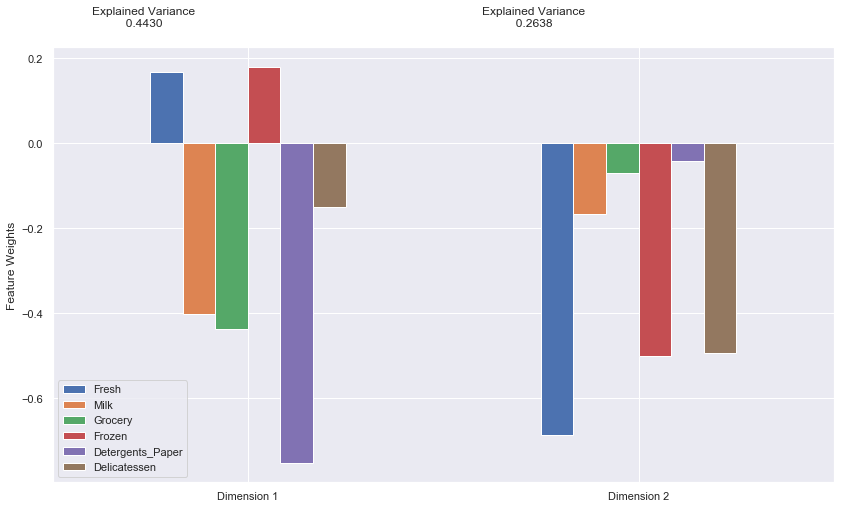

```python
pca_results(good_data, pca)
```

### Observation

Run the code below to see how the log-transformed sample data has changed after having a PCA transformation applied to it using only two dimensions. Observe how the values for the first two dimensions remains unchanged when compared to a PCA transformation in six dimensions.

```python
pd.DataFrame(np.round(pca_samples, 4), columns = ['Dimension 1', 'Dimension 2'])
```

|  | Dimension 1 | Dimension 2 |
| --- | --- | --- |
| 0 | -1.2292 | 1.5540 |
| 1 | 1.1404 | -0.6710 |
| 2 | 8.3026 | -0.4747 |

## Visualizing a Biplot

A biplot is a scatterplot where each data point is represented by its scores along the principal components. The axes are the principal components (in this case Dimension 1 and Dimension 2). In addition, the biplot shows the projection of the original features along the components. A biplot can help us interpret the reduced dimensions of the data, and discover relationships between the principal components and original features.

Run the code cell below to produce a biplot of the reduced-dimension data

```python
def biplot(good_data, reduced_data, pca):
    '''
    Produce a biplot that shows a scatterplot of the reduced
    data and the projections of the original features.

    good_data: original data, before transformation.
               Needs to be a pandas dataframe with valid column names
    reduced_data: the reduced data (the first two dimensions are plotted)
    pca: pca object that contains the components_ attribute

    return: a matplotlib AxesSubplot object (for any additional customization)

    This procedure is inspired by the script:
    https://github.com/teddyroland/python-biplot
    '''

    fig, ax = plt.subplots(figsize = (14,8))
    # scatterplot of the reduced data
    ax.scatter(x=reduced_data.loc[:, 'Dimension 1'], y=reduced_data.loc[:, 'Dimension 2'],
        facecolors='b', edgecolors='b', s=70, alpha=0.5)

    feature_vectors = pca.components_.T

    # we use scaling factors to make the arrows easier to see
    arrow_size, text_pos = 7.0, 8.0,

    # projections of the original features
    for i, v in enumerate(feature_vectors):
        ax.arrow(0, 0, arrow_size*v[0], arrow_size*v[1],
                  head_width=0.2, head_length=0.2, linewidth=2, color='red')
        ax.text(v[0]*text_pos, v[1]*text_pos, good_data.columns[i], color='black',
                 ha='center', va='center', fontsize=18)

    ax.set_xlabel("Dimension 1", fontsize=14)
    ax.set_ylabel("Dimension 2", fontsize=14)
    ax.set_title("PC plane with original feature projections.", fontsize=16);
    return ax
```

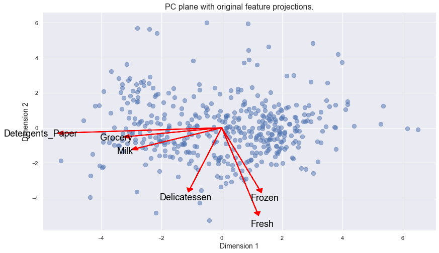

```python
# Create a biplot
biplot(good_data, reduced_data, pca)
```

## Clustering

In this section, you will choose to use either a K-Means clustering algorithm or a Gaussian Mixture Model clustering algorithm to identify the various customer segments hidden in the data. You will then recover specific data points from the clusters to understand their significance by transforming them back into their original dimension and scale.

### Question 6

- What are the advantages to using a K-Means clustering algorithm?
- What are the advantages to using a Gaussian Mixture Model clustering algorithm?
- Given your observations about the wholesale customer data so far, which of the two algorithms will you use and why?

**Answer:**

- **K-means Clustering:**
  - Advantages
    1. With a large number of features, K-means can be computationally faster if K is small.
    2. K-Means could result in tighter clusters than hierarchical clustering.
  - Disadvantages
    1. Difficulty in comparing quality of the clusters produced.
    2. K-means is highly sensitive to outliers.
    3. Since preset K value is required, it could be difficult to predict which K is best.
    4. K-means assigns data poins to the closest cluster in terms of Euclidian distance. Thus, it treats distances in all directions equally. Hence k-Means produces only spherical clusters. Assumes data is globular with doesn't always occur in real-life data.
    5. K-means is a ligher version of GMM, it can be seen as a special (limit) case of GMMs, specifically as GMM with diagonal, equal and small covariance matrices.
- **Gaussian Mixture Model (GMM):**
  - Advantages
    1. Capable of "soft" classification. That is, each data point is assigned a probability for each cluster, indicating how likely it belongs to the cluster. K-means only provides hard assignments, i.e., it chooses a single cluster for each data point.
    2. If you think that your model is having some hidden, not observable parameters, then you should use GMM. This is because, this algorithm is assigning a probability to each point to belong to certain cluster, instead of assigning a flag that the point belongs to certain cluster as in the classical k-Means.
    3. Works with different distributions of the data. It can fit more complex cluster shapes since each mixture component can freely fit its covariance matrix.
  - Disadvantages
    1. Could fail if the dimensionality of the problem is too high.
    2. For GMMs, many parameters must be fitted to the data (quadratic in the number of features) while k-means only maintains cluster centers (linear in number of features). Hence, take more time than K Means to train the data.
- **Choosing The Final Algorithim:**

  the chosen algorithim is Gaussian Mixture Model because of its ability to apply "soft" classification and since we've reduced the dimensionality of the problem with PCA, GMM should be able to do the job. If our dataset was considerably larger, we could reconsider and use K-means.

### Implementation: Creating Clusters

Depending on the problem, the number of clusters that you expect to be in the data may already be known. When the number of clusters is not known *a priori*, there is no guarantee that a given number of clusters best segments the data, since it is unclear what structure exists in the data — if any. However, we can quantify the "goodness" of a clustering by calculating each data point's *silhouette coefficient*. The [silhouette coefficient](http://scikit-learn.org/stable/modules/generated/sklearn.metrics.silhouette_score.html) for a data point measures how similar it is to its assigned cluster from -1 (dissimilar) to 1 (similar). Calculating the *mean* silhouette coefficient provides for a simple scoring method of a given clustering.

In the code block below, you will need to implement the following:

- Fit a clustering algorithm to the `reduced_data` and assign it to `clusterer`.
- Predict the cluster for each data point in `reduced_data` using `clusterer.predict` and assign them to `preds`.
- Find the cluster centers using the algorithm's respective attribute and assign them to `centers`.
- Predict the cluster for each sample data point in `pca_samples` and assign them `sample_preds`.
- Import `sklearn.metrics.silhouette_score` and calculate the silhouette score of `reduced_data` against `preds`.
  - Assign the silhouette score to `score` and print the result.

## GMM Implimentation :

```python
from sklearn.mixture import GaussianMixture
from sklearn.metrics import silhouette_score

def produceGaussianMixture(k):
    # TODO: Apply your clustering algorithm of choice to the reduced data
    clusterer = GaussianMixture(n_components=k, random_state=0).fit(reduced_data)

    # TODO: Predict the cluster for each data point
    preds = clusterer.predict(reduced_data)

    # TODO: Find the cluster centers
    centers = clusterer.means_

    # TODO: Predict the cluster for each transformed sample data point
    sample_preds = clusterer.predict(pca_samples)

    # TODO: Calculate the mean silhouette coefficient for the number of clusters chosen
    score = silhouette_score(reduced_data,preds)
    return score

results = pd.DataFrame(columns=['Silhouette Score'])
results.columns.name = 'Number of Clusters'
for k in range(2,13):
    score = produceGaussianMixture(k)
    results = results.append(pd.DataFrame([score],columns=['Silhouette Score'],index=[k]))

results
```

| Number of Clusters | Silhouette Score |
| --- | --- |
| 2 | 0.421917 |
| 3 | 0.374202 |
| 4 | 0.329080 |
| 5 | 0.305875 |
| 6 | 0.224815 |
| 7 | 0.274334 |
| 8 | 0.344370 |
| 9 | 0.334324 |
| 10 | 0.340632 |
| 11 | 0.319716 |
| 12 | 0.321553 |

**Answer:**

### Cluster Visualization

Once you've chosen the optimal number of clusters for your clustering algorithm using the scoring metric above, you can now visualize the results by executing the code block below

```python
def cluster_results(reduced_data, preds, centers, pca_samples):
	'''
	Visualizes the PCA-reduced cluster data in two dimensions
	Adds cues for cluster centers and student-selected sample data
	'''

	predictions = pd.DataFrame(preds, columns = ['Cluster'])
	plot_data = pd.concat([predictions, reduced_data], axis = 1)

	# Generate the cluster plot
	fig, ax = plt.subplots(figsize = (14,8))

	# Color map
	cmap = cm.get_cmap('gist_rainbow')

	# Color the points based on assigned cluster
	for i, cluster in plot_data.groupby('Cluster'):
	    cluster.plot(ax = ax, kind = 'scatter', x = 'Dimension 1', y = 'Dimension 2', \
	                 color = cmap((i)*1.0/(len(centers)-1)), label = 'Cluster %i'%(i), s=30);

	# Plot centers with indicators
	for i, c in enumerate(centers):
	    ax.scatter(x = c[0], y = c[1], color = 'white', edgecolors = 'black', \
	               alpha = 1, linewidth = 2, marker = 'o', s=200);
	    ax.scatter(x = c[0], y = c[1], marker='$%d$'%(i), alpha = 1, s=100);

	# Plot transformed sample points
	ax.scatter(x = pca_samples[:,0], y = pca_samples[:,1], \
	           s = 150, linewidth = 4, color = 'black', marker = 'x');

	# Set plot title
	ax.set_title("Cluster Learning on PCA-Reduced Data - Centroids Marked by Number\nTransformed Sample Data Marked by Black Cross");
```

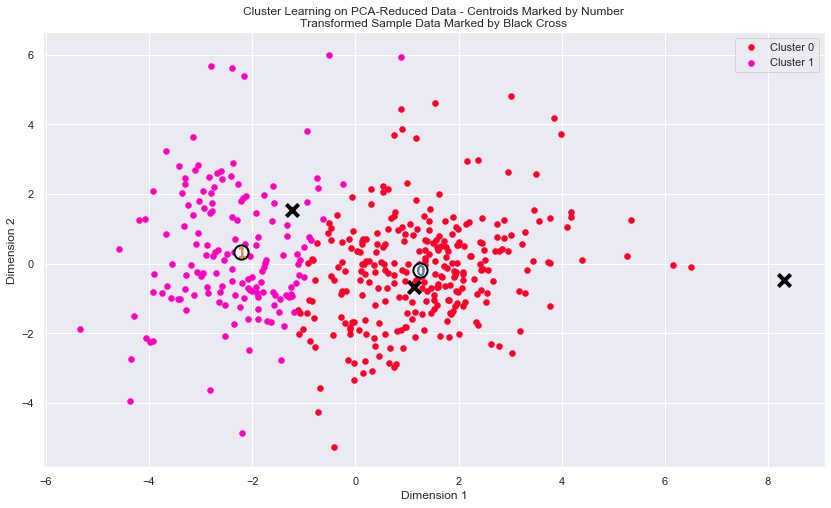

```python
#As per GMM Result

clusterer = GaussianMixture(n_components=2, random_state=0).fit(reduced_data)
preds = clusterer.predict(reduced_data)
centers = clusterer.means_

# Display the results of the clustering from implementation
cluster_results(reduced_data, preds, centers, pca_samples)
```

### Implementation: Data Recovery

Each cluster present in the visualization above has a central point. These centers (or means) are not specifically data points from the data, but rather the averages of all the data points predicted in the respective clusters. For the problem of creating customer segments, a cluster's center point corresponds to the average customer of that segment. Since the data is currently reduced in dimension and scaled by a logarithm, we can recover the representative customer spending from these data points by applying the inverse transformations.

In the code block below, you will need to implement the following:

- Apply the inverse transform to `centers` using `pca.inverse_transform` and assign the new centers to `log_centers`.
- Apply the inverse function of `np.log` to `log_centers` using `np.exp` and assign the true centers to `true_centers`.

```python
# TODO: Inverse transform the centers
log_centers = pca.inverse_transform(centers)

# TODO: Exponentiate the centers
true_centers = np.exp(log_centers)

# Display the true centers
segments = ['Segment {}'.format(i) for i in range(0,len(centers))]
true_centers = pd.DataFrame(np.round(true_centers), columns = data.columns)
true_centers.index = segments
true_centers
```

|  | Fresh | Milk | Grocery | Frozen | Detergents_Paper | Delicatessen |
| --- | --- | --- | --- | --- | --- | --- |
| Segment 0 | 8953.0 | 2114.0 | 2765.0 | 2075.0 | 353.0 | 732.0 |
| Segment 1 | 3552.0 | 7837.0 | 12219.0 | 870.0 | 4696.0 | 962.0 |

```python
data.mean()
```

```
Fresh               12000.297727
Milk                 5796.265909
Grocery              7951.277273
Frozen               3071.931818
Detergents_Paper     2881.493182
Delicatessen         1524.870455
dtype: float64
```

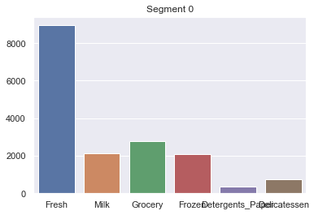

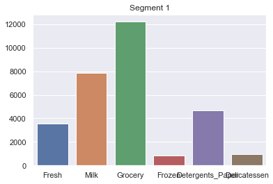

```python
plt.figure()
plt.axes().set_title("Segment 0")
sns.barplot(x=true_centers.columns.values,y=true_centers.iloc[0].values)

plt.figure()
plt.axes().set_title("Segment 1")
sns.barplot(x=true_centers.columns.values,y=true_centers.iloc[1].values)
```

**Answer:**

- **Cluster/Segment 0:** This most likely represents **cafes/restaurants** serving fresh food due to the strong weight upon the Fresh category. Whilst the volume falls below the overall population mean, it is consistent with the original prediction for what a Restaurant might look like in the Data Explotation section.
- **Cluster/Segment 1:** The quantities of Grocery and Milk are predominant here. The Milk and Grocery values in this cluster exceed the overall means observed in the Data Exploration section, which suggests the are bulk distributors or large resellers such as **Bulk Distributor / Supermarkets**.

### Question 9

- For each sample point, which customer segment from **Question 8** best represents it?
- Are the predictions for each sample point consistent with this?*

Run the code block below to find which cluster each sample point is predicted to be.

```python
sample_preds = clusterer.predict(pca_samples)
# Display the predictions
for i, pred in enumerate(sample_preds):
    print("Sample point", i, "predicted to be in Cluster", pred)
```

```
Sample point 0 predicted to be in Cluster 1
Sample point 1 predicted to be in Cluster 0
Sample point 2 predicted to be in Cluster 0
```

```python
pd.concat([samples, pd.DataFrame(list(sample_preds),index=[25,50,75],columns=['Customer Type'])], axis = 1)
```

|  | Fresh | Milk | Grocery | Frozen | Detergents_Paper | Delicatessen | Customer Type |
| --- | --- | --- | --- | --- | --- | --- | --- |
| 25 | 16165 | 4230 | 7595 | 201 | 4003 | 57 | 1 |
| 50 | 6269 | 1095 | 1980 | 3860 | 609 | 2162 | 0 |
| 75 | 20398 | 1137 | 3 | 4407 | 3 | 975 | 0 |

**Answer:**

### Customer Index : 25 (Index 0)

- **Past Conclusion:** *Small Retail Store.*
- **New Model Prediction:** *Bulk Distributor/Supermarket*
- **Comment:** Seems bit agree with the original prediction.

### Customer Index : 50 (Index 1)

- **Past Conclusion:** *Resturent.*
- **New Model Prediction:** *Cafes/Restaurants*
- **Comment:** Abolutely agrees with the original prediction.

### Customer Index : 75 (Index 2)

- **Past Conclusion:** *Supplier (with Small Resturent Business) / Supermarket (with attached Small Resturent)*
- **New Model Prediction:** *Cafes/Restaurants*
- **Comment:** Seems little agreement with the original prediction, but dissimilarity is at greater extent.

## Conclusion

In this final section, we investigate ways that we make use of the clustered data. First, we consider how the different groups of customers, the *customer segments*, may be affected differently by a specific delivery scheme. Next, we consider how giving a label to each customer (which *segment* that customer belongs to) can provide for additional features about the customer data. Finally, we compare the *customer segments* to a hidden variable present in the data, to see whether the clustering identified certain relationships.